# Descriptive Statistics

Erin Buchanan

2025-03-13

The links to the language files can be found in our supplemental materials. The paper is presented with an upcoming *R* package `semanticprimeR` that allows one to open data files directly in *R* and a Shiny application to download a specific set of language files (Chang et al. 2023; The Doom Lab and Buchanan 2024). The data can be cited using our Zenodo doi (Buchanan et al. 2024) which will indicate which version of the data was examined.

# Priming data

In a separate file, we prepared information about priming results which includes the target word, average response latencies, averaged *Z*-scored response latencies, sample sizes, standard errors, and priming response latency. For each item, priming was defined as the average *Z*-scored response latency when presented in the unrelated minus the related condition. Therefore, the timing for DOG-CAT would be subtracted from BUS-CAT to indicate priming for the word CAT. The similarity scores calculated during stimuli selection are provided for merging, as well as other popular measures of similarity if they are available in that language. For example, semantic feature overlap norms are also available in Italian (Montefinese et al. 2013), German (Kremer and Baroni 2011), Spanish (Aguasvivas et al. 2018), and Dutch (Ruts et al. 2004).

## Original Accuracy Priming Scores

### Priming Averages

| Language | M Z | M Z2.5 | M Z3.0 | M UR Z | M UR Z2.5 | M UR Z3.0 | M R Z | M R Z2.5 | M R Z3.0 | N UR | N R |
| --- | --- | --- | --- | --- | --- | --- | --- | --- | --- | --- | --- |
| br_pt | 0.09 | 0.08 | 0.08 | -0.33 | -0.38 | -0.37 | -0.41 | -0.46 | -0.45 | 68.84 | 78.33 |
| cs | 0.12 | 0.10 | 0.10 | -0.34 | -0.39 | -0.38 | -0.45 | -0.49 | -0.48 | 80.38 | 80.78 |
| da | 0.11 | 0.10 | 0.10 | -0.28 | -0.35 | -0.33 | -0.40 | -0.45 | -0.44 | 64.17 | 64.17 |
| de | 0.13 | 0.11 | 0.12 | -0.27 | -0.33 | -0.32 | -0.39 | -0.44 | -0.43 | 201.93 | 202.30 |
| el | 0.09 | 0.08 | 0.08 | -0.22 | -0.30 | -0.28 | -0.31 | -0.38 | -0.36 | 52.12 | 52.04 |
| en | 0.09 | 0.08 | 0.08 | -0.28 | -0.35 | -0.33 | -0.37 | -0.43 | -0.41 | 415.05 | 417.43 |
| es | 0.12 | 0.10 | 0.11 | -0.33 | -0.39 | -0.37 | -0.45 | -0.49 | -0.48 | 108.49 | 108.54 |
| fr | 0.11 | 0.10 | 0.10 | -0.31 | -0.37 | -0.36 | -0.42 | -0.47 | -0.46 | 63.89 | 63.87 |
| hu | 0.11 | 0.09 | 0.09 | -0.21 | -0.29 | -0.28 | -0.32 | -0.38 | -0.37 | 57.18 | 57.41 |
| it | 0.13 | 0.12 | 0.12 | -0.32 | -0.38 | -0.37 | -0.46 | -0.50 | -0.49 | 81.33 | 80.93 |
| ja | 0.15 | 0.12 | 0.13 | -0.22 | -0.31 | -0.29 | -0.37 | -0.43 | -0.42 | 80.19 | 80.27 |
| ko | 0.13 | 0.12 | 0.12 | -0.25 | -0.33 | -0.31 | -0.38 | -0.44 | -0.43 | 67.80 | 70.54 |
| pl | 0.13 | 0.11 | 0.12 | -0.30 | -0.36 | -0.35 | -0.43 | -0.47 | -0.46 | 90.13 | 90.30 |
| pt | 0.09 | 0.08 | 0.08 | -0.33 | -0.39 | -0.38 | -0.42 | -0.47 | -0.46 | 69.42 | 78.16 |
| ro | 0.11 | 0.10 | 0.10 | -0.34 | -0.39 | -0.38 | -0.45 | -0.49 | -0.48 | 55.66 | 55.66 |
| ru | 0.12 | 0.11 | 0.11 | -0.32 | -0.37 | -0.36 | -0.44 | -0.48 | -0.47 | 137.99 | 137.09 |
| sr | 0.14 | 0.14 | 0.14 | -0.37 | -0.42 | -0.40 | -0.52 | -0.55 | -0.54 | 52.19 | 52.24 |
| tr | 0.10 | 0.09 | 0.09 | -0.26 | -0.33 | -0.32 | -0.37 | -0.42 | -0.41 | 160.55 | 161.37 |
| zh | 0.15 | 0.13 | 0.14 | -0.26 | -0.34 | -0.32 | -0.41 | -0.47 | -0.46 | 60.57 | 61.03 |
| Overall | 0.12 | 0.10 | 0.11 | -0.29 | -0.36 | -0.34 | -0.41 | -0.46 | -0.45 | 103.51 | 104.87 |

Note. UR = Unrelated trials, R = related trials, M = mean Z-scored response latency, N = mean number of trials.

### Priming Standard Errors

| Language | SE Z | SE Z2.5 | SE Z3.0 | SE UR Z | SE UR Z2.5 | SE UR Z3.0 | SE R Z | SE R Z2.5 | SE R Z3.0 | N UR | N R |
| --- | --- | --- | --- | --- | --- | --- | --- | --- | --- | --- | --- |
| br_pt | 0.01 | 0.00 | 0.01 | 0.09 | 0.08 | 0.08 | 0.08 | 0.07 | 0.07 | 68.84 | 78.33 |
| cs | 0.01 | 0.00 | 0.00 | 0.08 | 0.07 | 0.07 | 0.08 | 0.06 | 0.07 | 80.38 | 80.78 |
| da | 0.01 | 0.01 | 0.01 | 0.10 | 0.08 | 0.08 | 0.09 | 0.07 | 0.08 | 64.17 | 64.17 |
| de | 0.00 | 0.00 | 0.00 | 0.06 | 0.04 | 0.05 | 0.05 | 0.04 | 0.04 | 201.93 | 202.30 |
| el | 0.01 | 0.01 | 0.01 | 0.11 | 0.09 | 0.09 | 0.11 | 0.09 | 0.09 | 52.12 | 52.04 |
| en | 0.00 | 0.00 | 0.00 | 0.04 | 0.03 | 0.03 | 0.04 | 0.03 | 0.03 | 415.05 | 417.43 |
| es | 0.01 | 0.00 | 0.00 | 0.08 | 0.06 | 0.06 | 0.07 | 0.06 | 0.06 | 108.49 | 108.54 |
| fr | 0.01 | 0.01 | 0.01 | 0.10 | 0.08 | 0.08 | 0.09 | 0.07 | 0.08 | 63.89 | 63.87 |
| hu | 0.01 | 0.01 | 0.01 | 0.11 | 0.09 | 0.09 | 0.10 | 0.08 | 0.09 | 57.18 | 57.41 |
| it | 0.01 | 0.00 | 0.01 | 0.09 | 0.07 | 0.07 | 0.08 | 0.07 | 0.07 | 81.33 | 80.93 |
| ja | 0.01 | 0.01 | 0.01 | 0.09 | 0.07 | 0.07 | 0.09 | 0.07 | 0.07 | 80.19 | 80.27 |
| ko | 0.01 | 0.01 | 0.01 | 0.10 | 0.08 | 0.08 | 0.09 | 0.07 | 0.07 | 67.80 | 70.54 |
| pl | 0.01 | 0.00 | 0.00 | 0.09 | 0.07 | 0.07 | 0.08 | 0.06 | 0.07 | 90.13 | 90.30 |
| pt | 0.01 | 0.00 | 0.00 | 0.09 | 0.08 | 0.08 | 0.08 | 0.07 | 0.07 | 69.42 | 78.16 |
| ro | 0.01 | 0.01 | 0.01 | 0.10 | 0.08 | 0.09 | 0.09 | 0.08 | 0.08 | 55.66 | 55.66 |
| ru | 0.01 | 0.00 | 0.01 | 0.07 | 0.06 | 0.06 | 0.06 | 0.06 | 0.06 | 137.99 | 137.09 |
| sr | 0.01 | 0.01 | 0.01 | 0.10 | 0.09 | 0.09 | 0.09 | 0.08 | 0.08 | 52.19 | 52.24 |
| tr | 0.01 | 0.00 | 0.00 | 0.07 | 0.05 | 0.06 | 0.06 | 0.05 | 0.05 | 160.55 | 161.37 |
| zh | 0.01 | 0.01 | 0.01 | 0.12 | 0.09 | 0.09 | 0.11 | 0.08 | 0.09 | 60.57 | 61.03 |
| Overall | 0.00 | 0.00 | 0.00 | 0.09 | 0.07 | 0.07 | 0.08 | 0.07 | 0.07 | 103.51 | 104.87 |

Note. UR = Unrelated trials, R = related trials, SE = standard error, N = mean number of trials.

### Raw RT Averages

| Language | M RT | M RT Z2.5 | M RT Z3.0 | M UR RT | M UR RT Z2.5 | M UR RT Z3.0 | M R RT | M R RT Z2.5 | M R RT Z3.0 | N UR | N R |
| --- | --- | --- | --- | --- | --- | --- | --- | --- | --- | --- | --- |
| br_pt | 29.70 | 26.73 | 28.19 | 639.23 | 623.51 | 628.32 | 609.53 | 596.78 | 600.12 | 68.84 | 78.33 |
| cs | 31.91 | 28.41 | 29.08 | 708.61 | 694.34 | 697.95 | 676.69 | 665.93 | 668.87 | 80.38 | 80.78 |
| da | 31.70 | 28.05 | 29.50 | 650.97 | 632.41 | 637.52 | 619.27 | 604.36 | 608.02 | 64.17 | 64.17 |
| de | 32.90 | 29.21 | 30.19 | 666.15 | 648.89 | 653.13 | 633.24 | 619.68 | 622.94 | 201.93 | 202.30 |
| el | 24.19 | 21.36 | 22.14 | 662.98 | 642.86 | 647.46 | 638.80 | 621.50 | 625.32 | 52.12 | 52.04 |
| en | 22.64 | 19.78 | 20.28 | 600.29 | 581.90 | 586.01 | 577.65 | 562.12 | 565.73 | 415.05 | 417.43 |
| es | 27.70 | 24.95 | 25.44 | 596.35 | 582.69 | 585.81 | 568.65 | 557.74 | 560.37 | 108.49 | 108.54 |
| fr | 24.68 | 22.17 | 23.10 | 602.96 | 587.81 | 591.34 | 578.28 | 565.64 | 568.24 | 63.89 | 63.87 |
| hu | 25.66 | 21.25 | 22.15 | 630.05 | 609.75 | 614.34 | 604.70 | 588.80 | 592.49 | 57.18 | 57.41 |
| it | 30.41 | 27.04 | 27.66 | 609.95 | 596.01 | 599.16 | 579.54 | 568.97 | 571.50 | 81.33 | 80.93 |
| ja | 37.72 | 31.09 | 32.65 | 699.01 | 676.76 | 681.74 | 661.29 | 645.67 | 649.09 | 80.19 | 80.27 |
| ko | 30.91 | 28.05 | 28.29 | 614.20 | 595.29 | 598.99 | 584.53 | 568.38 | 571.83 | 67.80 | 70.54 |
| pl | 32.49 | 28.19 | 29.49 | 653.86 | 637.45 | 641.76 | 621.37 | 609.26 | 612.26 | 90.13 | 90.30 |
| pt | 19.22 | 16.96 | 17.44 | 617.64 | 602.70 | 606.59 | 598.42 | 585.74 | 589.15 | 69.42 | 78.16 |
| ro | 30.92 | 29.11 | 29.67 | 662.29 | 647.97 | 651.70 | 631.36 | 618.86 | 622.03 | 55.66 | 55.66 |
| ru | 32.88 | 29.60 | 30.09 | 708.44 | 694.86 | 698.76 | 675.55 | 665.27 | 668.67 | 137.99 | 137.09 |
| sr | 51.00 | 48.97 | 49.69 | 753.03 | 739.92 | 744.31 | 702.02 | 690.95 | 694.62 | 52.19 | 52.24 |
| tr | 26.81 | 22.65 | 23.76 | 634.26 | 614.95 | 619.40 | 607.46 | 592.30 | 595.64 | 160.55 | 161.37 |
| zh | 38.19 | 33.44 | 34.66 | 620.82 | 598.36 | 603.19 | 582.62 | 564.91 | 568.52 | 60.57 | 61.03 |
| Overall | 30.61 | 27.21 | 28.08 | 648.94 | 631.96 | 636.12 | 618.47 | 604.89 | 608.18 | 103.51 | 104.87 |

Note. UR = Unrelated trials, R = related trials, M = mean raw response times, N = mean number of trials. Note that the Z-scores were used to eliminate outlier trials for this calculation.

### Raw RT Standard Errors

| Language | SE RT | SE RT Z2.5 | SE RT Z3.0 | SE UR RT | SE UR RT Z2.5 | SE UR RT Z3.0 | SE R RT | SE R RT Z2.5 | SE R RT Z3.0 | N UR | N R |
| --- | --- | --- | --- | --- | --- | --- | --- | --- | --- | --- | --- |
| br_pt | 1.95 | 1.66 | 1.73 | 30.84 | 26.09 | 27.36 | 26.79 | 22.74 | 23.60 | 68.84 | 78.33 |
| cs | 1.65 | 1.41 | 1.46 | 27.22 | 23.49 | 24.24 | 24.93 | 21.79 | 22.50 | 80.38 | 80.78 |
| da | 2.12 | 1.78 | 1.87 | 32.86 | 27.06 | 28.38 | 30.33 | 25.26 | 26.31 | 64.17 | 64.17 |
| de | 1.27 | 1.08 | 1.11 | 17.86 | 14.78 | 15.38 | 16.37 | 13.66 | 14.17 | 201.93 | 202.30 |
| el | 2.04 | 1.69 | 1.73 | 34.36 | 28.82 | 29.90 | 32.50 | 27.41 | 28.44 | 52.12 | 52.04 |
| en | 0.96 | 0.81 | 0.84 | 12.53 | 9.74 | 10.23 | 11.71 | 9.19 | 9.66 | 415.05 | 417.43 |
| es | 1.57 | 1.35 | 1.39 | 21.35 | 17.66 | 18.32 | 19.74 | 16.42 | 17.07 | 108.49 | 108.54 |
| fr | 1.61 | 1.32 | 1.38 | 26.45 | 21.41 | 22.34 | 24.57 | 20.05 | 20.78 | 63.89 | 63.87 |
| hu | 1.93 | 1.53 | 1.59 | 31.38 | 25.26 | 26.40 | 28.93 | 23.75 | 24.69 | 57.18 | 57.41 |
| it | 1.52 | 1.25 | 1.30 | 23.81 | 19.74 | 20.47 | 21.80 | 18.33 | 19.00 | 81.33 | 80.93 |
| ja | 2.39 | 1.94 | 2.02 | 28.33 | 22.79 | 23.91 | 25.85 | 21.46 | 22.23 | 80.19 | 80.27 |
| ko | 2.12 | 1.73 | 1.77 | 27.68 | 21.57 | 22.49 | 25.26 | 19.50 | 20.51 | 67.80 | 70.54 |
| pl | 1.59 | 1.33 | 1.40 | 25.91 | 21.49 | 22.45 | 23.19 | 19.66 | 20.37 | 90.13 | 90.30 |
| pt | 1.78 | 1.53 | 1.59 | 29.13 | 24.57 | 25.49 | 26.24 | 22.17 | 23.07 | 69.42 | 78.16 |
| ro | 2.11 | 1.82 | 1.88 | 32.76 | 28.46 | 29.38 | 30.48 | 26.02 | 27.02 | 55.66 | 55.66 |
| ru | 1.62 | 1.50 | 1.52 | 23.59 | 21.15 | 21.81 | 21.96 | 19.92 | 20.59 | 137.99 | 137.09 |
| sr | 2.40 | 2.16 | 2.23 | 40.77 | 37.48 | 38.40 | 36.42 | 32.98 | 34.06 | 52.19 | 52.24 |
| tr | 1.42 | 1.21 | 1.27 | 20.20 | 16.27 | 16.97 | 18.70 | 15.30 | 15.90 | 160.55 | 161.37 |
| zh | 2.16 | 1.73 | 1.82 | 33.88 | 26.16 | 27.47 | 30.50 | 24.01 | 25.15 | 60.57 | 61.03 |
| Overall | 0.42 | 0.36 | 0.37 | 27.42 | 22.84 | 23.76 | 25.07 | 21.03 | 21.85 | 103.51 | 104.87 |

Note. UR = Unrelated trials, R = related trials, SE = standard error, N = mean number of trials. Note that the Z-scores were used to eliminate outlier trials for this calculation.

## Rescored Acccuracy Priming Scores

### Priming Averages

| Language | M Z | M Z2.5 | M Z3.0 | M UR Z | M UR Z2.5 | M UR Z3.0 | M R Z | M R Z2.5 | M R Z3.0 | N UR | N R |
| --- | --- | --- | --- | --- | --- | --- | --- | --- | --- | --- | --- |
| br_pt | 0.09 | 0.08 | 0.08 | -0.32 | -0.38 | -0.36 | -0.41 | -0.46 | -0.45 | 68.84 | 78.33 |
| cs | 0.11 | 0.10 | 0.10 | -0.34 | -0.39 | -0.38 | -0.45 | -0.49 | -0.48 | 80.38 | 80.78 |
| da | 0.11 | 0.10 | 0.10 | -0.29 | -0.35 | -0.33 | -0.40 | -0.45 | -0.44 | 64.17 | 64.17 |
| de | 0.13 | 0.11 | 0.12 | -0.27 | -0.33 | -0.32 | -0.39 | -0.44 | -0.43 | 201.93 | 202.30 |
| el | 0.09 | 0.08 | 0.08 | -0.22 | -0.30 | -0.28 | -0.31 | -0.38 | -0.36 | 52.12 | 52.04 |
| en | 0.09 | 0.08 | 0.08 | -0.28 | -0.35 | -0.33 | -0.37 | -0.43 | -0.41 | 415.05 | 417.43 |
| es | 0.11 | 0.10 | 0.11 | -0.33 | -0.39 | -0.37 | -0.44 | -0.49 | -0.48 | 108.49 | 108.54 |
| fr | 0.11 | 0.10 | 0.10 | -0.31 | -0.38 | -0.36 | -0.42 | -0.48 | -0.46 | 63.89 | 63.87 |
| hu | 0.11 | 0.09 | 0.09 | -0.21 | -0.29 | -0.28 | -0.32 | -0.38 | -0.37 | 57.18 | 57.41 |
| it | 0.13 | 0.12 | 0.12 | -0.32 | -0.38 | -0.37 | -0.46 | -0.50 | -0.49 | 81.33 | 80.93 |
| ja | 0.15 | 0.12 | 0.13 | -0.22 | -0.31 | -0.29 | -0.37 | -0.43 | -0.42 | 80.19 | 80.27 |
| ko | 0.13 | 0.12 | 0.12 | -0.25 | -0.33 | -0.31 | -0.37 | -0.44 | -0.43 | 67.80 | 70.54 |
| pl | 0.13 | 0.11 | 0.11 | -0.30 | -0.36 | -0.35 | -0.43 | -0.47 | -0.46 | 90.13 | 90.30 |
| pt | 0.09 | 0.08 | 0.08 | -0.33 | -0.39 | -0.37 | -0.42 | -0.47 | -0.46 | 69.42 | 78.16 |
| ro | 0.11 | 0.10 | 0.10 | -0.34 | -0.39 | -0.38 | -0.45 | -0.49 | -0.48 | 55.66 | 55.66 |
| ru | 0.12 | 0.11 | 0.11 | -0.32 | -0.37 | -0.36 | -0.44 | -0.48 | -0.47 | 137.99 | 137.09 |
| sr | 0.14 | 0.14 | 0.14 | -0.37 | -0.42 | -0.40 | -0.52 | -0.55 | -0.54 | 52.19 | 52.24 |
| tr | 0.10 | 0.09 | 0.09 | -0.26 | -0.33 | -0.32 | -0.37 | -0.42 | -0.41 | 160.55 | 161.37 |
| zh | 0.15 | 0.13 | 0.14 | -0.26 | -0.34 | -0.32 | -0.40 | -0.47 | -0.46 | 60.57 | 61.03 |
| Overall | 0.12 | 0.10 | 0.11 | -0.29 | -0.36 | -0.34 | -0.41 | -0.46 | -0.45 | 103.51 | 104.87 |

Note. UR = Unrelated trials, R = related trials, M = mean Z-scored response latency, N = mean number of trials.

### Priming Standard Errors

| Language | SE Z | SE Z2.5 | SE Z3.0 | SE UR Z | SE UR Z2.5 | SE UR Z3.0 | SE R Z | SE R Z2.5 | SE R Z3.0 | N UR | N R |
| --- | --- | --- | --- | --- | --- | --- | --- | --- | --- | --- | --- |
| br_pt | 0.01 | 0.00 | 0.01 | 0.09 | 0.08 | 0.08 | 0.08 | 0.07 | 0.07 | 68.84 | 78.33 |
| cs | 0.01 | 0.00 | 0.00 | 0.08 | 0.07 | 0.07 | 0.08 | 0.06 | 0.07 | 80.38 | 80.78 |
| da | 0.01 | 0.01 | 0.01 | 0.10 | 0.08 | 0.08 | 0.09 | 0.07 | 0.08 | 64.17 | 64.17 |
| de | 0.00 | 0.00 | 0.00 | 0.06 | 0.04 | 0.05 | 0.05 | 0.04 | 0.04 | 201.93 | 202.30 |
| el | 0.01 | 0.01 | 0.01 | 0.11 | 0.09 | 0.09 | 0.11 | 0.09 | 0.09 | 52.12 | 52.04 |
| en | 0.00 | 0.00 | 0.00 | 0.04 | 0.03 | 0.03 | 0.04 | 0.03 | 0.03 | 415.05 | 417.43 |
| es | 0.01 | 0.00 | 0.00 | 0.08 | 0.06 | 0.06 | 0.07 | 0.06 | 0.06 | 108.49 | 108.54 |
| fr | 0.01 | 0.01 | 0.01 | 0.10 | 0.08 | 0.08 | 0.09 | 0.07 | 0.08 | 63.89 | 63.87 |
| hu | 0.01 | 0.01 | 0.01 | 0.11 | 0.09 | 0.09 | 0.10 | 0.08 | 0.09 | 57.18 | 57.41 |
| it | 0.01 | 0.00 | 0.01 | 0.09 | 0.07 | 0.07 | 0.08 | 0.07 | 0.07 | 81.33 | 80.93 |
| ja | 0.01 | 0.01 | 0.01 | 0.09 | 0.07 | 0.07 | 0.08 | 0.06 | 0.07 | 80.19 | 80.27 |
| ko | 0.01 | 0.01 | 0.01 | 0.10 | 0.07 | 0.08 | 0.09 | 0.07 | 0.07 | 67.80 | 70.54 |
| pl | 0.01 | 0.00 | 0.00 | 0.09 | 0.07 | 0.07 | 0.08 | 0.06 | 0.06 | 90.13 | 90.30 |
| pt | 0.01 | 0.00 | 0.00 | 0.09 | 0.07 | 0.08 | 0.08 | 0.07 | 0.07 | 69.42 | 78.16 |
| ro | 0.01 | 0.01 | 0.01 | 0.10 | 0.08 | 0.08 | 0.09 | 0.08 | 0.08 | 55.66 | 55.66 |
| ru | 0.01 | 0.00 | 0.00 | 0.07 | 0.06 | 0.06 | 0.06 | 0.05 | 0.06 | 137.99 | 137.09 |
| sr | 0.01 | 0.01 | 0.01 | 0.10 | 0.08 | 0.09 | 0.09 | 0.08 | 0.08 | 52.19 | 52.24 |
| tr | 0.01 | 0.00 | 0.00 | 0.07 | 0.05 | 0.05 | 0.06 | 0.05 | 0.05 | 160.55 | 161.37 |
| zh | 0.01 | 0.01 | 0.01 | 0.12 | 0.09 | 0.09 | 0.10 | 0.08 | 0.08 | 60.57 | 61.03 |
| Overall | 0.00 | 0.00 | 0.00 | 0.09 | 0.07 | 0.07 | 0.08 | 0.06 | 0.07 | 103.51 | 104.87 |

Note. UR = Unrelated trials, R = related trials, SE = standard error, N = mean number of trials.

### Raw RT Averages

| Language | M RT | M RT Z2.5 | M RT Z3.0 | M UR RT | M UR RT Z2.5 | M UR RT Z3.0 | M R RT | M R RT Z2.5 | M R RT Z3.0 | N UR | N R |
| --- | --- | --- | --- | --- | --- | --- | --- | --- | --- | --- | --- |
| br_pt | 30.22 | 27.12 | 28.53 | 640.16 | 624.36 | 629.11 | 609.94 | 597.23 | 600.58 | 68.84 | 78.33 |
| cs | 31.62 | 28.17 | 28.82 | 709.22 | 695.03 | 698.62 | 677.60 | 666.87 | 669.79 | 80.38 | 80.78 |
| da | 32.00 | 28.20 | 29.65 | 651.36 | 632.67 | 637.83 | 619.36 | 604.47 | 608.17 | 64.17 | 64.17 |
| de | 32.89 | 29.26 | 30.27 | 666.88 | 649.62 | 653.90 | 633.99 | 620.36 | 623.63 | 201.93 | 202.30 |
| el | 24.70 | 21.89 | 22.61 | 665.02 | 644.92 | 649.52 | 640.32 | 623.03 | 626.91 | 52.12 | 52.04 |
| en | 22.77 | 19.85 | 20.36 | 601.28 | 582.64 | 586.81 | 578.52 | 562.79 | 566.45 | 415.05 | 417.43 |
| es | 27.61 | 24.97 | 25.43 | 596.93 | 583.15 | 586.29 | 569.32 | 558.18 | 560.85 | 108.49 | 108.54 |
| fr | 24.74 | 22.20 | 23.16 | 603.14 | 588.02 | 591.56 | 578.40 | 565.82 | 568.40 | 63.89 | 63.87 |
| hu | 25.86 | 21.20 | 22.15 | 630.75 | 610.25 | 614.85 | 605.20 | 589.34 | 592.99 | 57.18 | 57.41 |
| it | 30.38 | 27.05 | 27.66 | 610.21 | 596.21 | 599.38 | 579.83 | 569.17 | 571.72 | 81.33 | 80.93 |
| ja | 37.69 | 31.22 | 32.77 | 700.10 | 677.67 | 682.64 | 662.41 | 646.45 | 649.87 | 80.19 | 80.27 |
| ko | 31.10 | 27.91 | 28.13 | 616.54 | 596.85 | 600.66 | 586.65 | 570.05 | 573.62 | 67.80 | 70.54 |
| pl | 32.27 | 27.96 | 29.23 | 655.09 | 638.53 | 642.88 | 622.82 | 610.57 | 613.65 | 90.13 | 90.30 |
| pt | 19.40 | 16.98 | 17.42 | 617.90 | 602.82 | 606.69 | 598.49 | 585.84 | 589.26 | 69.42 | 78.16 |
| ro | 31.05 | 29.40 | 30.11 | 664.43 | 649.98 | 653.93 | 633.38 | 620.58 | 623.83 | 55.66 | 55.66 |
| ru | 33.04 | 29.76 | 30.38 | 712.41 | 697.98 | 702.08 | 679.36 | 668.22 | 671.70 | 137.99 | 137.09 |
| sr | 51.07 | 48.96 | 49.67 | 753.65 | 740.47 | 744.96 | 702.58 | 691.50 | 695.28 | 52.19 | 52.24 |
| tr | 26.81 | 22.60 | 23.67 | 635.07 | 615.45 | 619.89 | 608.26 | 592.85 | 596.22 | 160.55 | 161.37 |
| zh | 37.96 | 33.49 | 34.80 | 623.55 | 600.80 | 605.73 | 585.60 | 567.31 | 570.93 | 60.57 | 61.03 |
| Overall | 30.69 | 27.27 | 28.15 | 650.13 | 632.96 | 637.16 | 619.58 | 605.82 | 609.15 | 103.51 | 104.87 |

Note. UR = Unrelated trials, R = related trials, M = mean raw response times, N = mean number of trials. Note that the Z-scores were used to eliminate outlier trials for this calculation.

### Raw RT Standard Errors

| Language | SE RT | SE RT Z2.5 | SE RT Z3.0 | SE UR RT | SE UR RT Z2.5 | SE UR RT Z3.0 | SE R RT | SE R RT Z2.5 | SE R RT Z3.0 | N UR | N R |
| --- | --- | --- | --- | --- | --- | --- | --- | --- | --- | --- | --- |
| br_pt | 1.95 | 1.66 | 1.73 | 30.87 | 26.16 | 27.40 | 26.74 | 22.76 | 23.59 | 68.84 | 78.33 |
| cs | 1.64 | 1.40 | 1.45 | 26.89 | 23.22 | 23.95 | 24.67 | 21.58 | 22.27 | 80.38 | 80.78 |
| da | 2.11 | 1.78 | 1.86 | 32.78 | 26.94 | 28.27 | 30.19 | 25.16 | 26.22 | 64.17 | 64.17 |
| de | 1.28 | 1.08 | 1.11 | 17.83 | 14.77 | 15.38 | 16.34 | 13.64 | 14.14 | 201.93 | 202.30 |
| el | 2.06 | 1.72 | 1.76 | 34.80 | 29.37 | 30.42 | 32.82 | 27.81 | 28.85 | 52.12 | 52.04 |
| en | 0.96 | 0.82 | 0.85 | 12.56 | 9.76 | 10.25 | 11.74 | 9.21 | 9.68 | 415.05 | 417.43 |
| es | 1.57 | 1.34 | 1.39 | 21.35 | 17.64 | 18.31 | 19.78 | 16.40 | 17.06 | 108.49 | 108.54 |
| fr | 1.61 | 1.32 | 1.38 | 26.40 | 21.37 | 22.31 | 24.51 | 20.02 | 20.74 | 63.89 | 63.87 |
| hu | 1.93 | 1.53 | 1.60 | 31.30 | 25.16 | 26.29 | 28.79 | 23.66 | 24.57 | 57.18 | 57.41 |
| it | 1.51 | 1.25 | 1.29 | 23.74 | 19.66 | 20.39 | 21.78 | 18.28 | 18.95 | 81.33 | 80.93 |
| ja | 2.41 | 1.95 | 2.03 | 28.04 | 22.56 | 23.65 | 25.78 | 21.31 | 22.07 | 80.19 | 80.27 |
| ko | 2.11 | 1.73 | 1.77 | 27.62 | 21.39 | 22.30 | 25.15 | 19.37 | 20.41 | 67.80 | 70.54 |
| pl | 1.60 | 1.35 | 1.41 | 25.85 | 21.45 | 22.41 | 23.20 | 19.65 | 20.38 | 90.13 | 90.30 |
| pt | 1.78 | 1.53 | 1.59 | 29.06 | 24.52 | 25.42 | 26.13 | 22.12 | 23.00 | 69.42 | 78.16 |
| ro | 2.05 | 1.74 | 1.82 | 32.81 | 28.56 | 29.55 | 30.90 | 26.38 | 27.41 | 55.66 | 55.66 |
| ru | 1.63 | 1.50 | 1.52 | 23.59 | 20.90 | 21.60 | 22.02 | 19.64 | 20.32 | 137.99 | 137.09 |
| sr | 2.39 | 2.17 | 2.23 | 40.58 | 37.32 | 38.24 | 36.14 | 32.73 | 33.85 | 52.19 | 52.24 |
| tr | 1.42 | 1.21 | 1.26 | 20.16 | 16.15 | 16.85 | 18.64 | 15.18 | 15.79 | 160.55 | 161.37 |
| zh | 2.17 | 1.76 | 1.84 | 34.47 | 26.83 | 28.15 | 31.31 | 24.70 | 25.78 | 60.57 | 61.03 |
| Overall | 0.42 | 0.36 | 0.37 | 27.41 | 22.83 | 23.74 | 25.09 | 21.03 | 21.85 | 103.51 | 104.87 |

Note. UR = Unrelated trials, R = related trials, SE = standard error, N = mean number of trials. Note that the Z-scores were used to eliminate outlier trials for this calculation.

## Reliability

Item reliability was calculated by randomly splitting priming trials into two halves, calculating *Z*-score priming for each half, and correlating those scores by item. Person level reliability was calculated in a similar fashion by splitting participant related-unrelated trials in half and calculating priming as the average unrelated *Z*-scored response latency minus the related *Z*-scored response latency, and correlating the two priming scores. TThe Spearman-Brown prophecy formula was applied to the average and median correlation across 100 trial runs to calculate total reliability. The Spearman-Brown prophecy formula was applied to the average and median correlation across 100 trial runs to calculate total reliability.

### Reliability for Original Accuracy

| Language | Item Reliability | Person Reliability |
| --- | --- | --- |
| br_pt | 0.33 | 0.09 |
| cs | 0.37 | -0.02 |
| da | 0.31 | 0.13 |
| de | 0.50 | -0.00 |
| el | 0.26 | 0.01 |
| en | 0.56 | 0.06 |
| es | 0.46 | 0.09 |
| fr | 0.30 | -0.07 |
| hu | 0.31 | 0.04 |
| it | 0.37 | 0.10 |
| ja | 0.58 | 0.17 |
| ko | 0.53 | 0.03 |
| pl | 0.35 | 0.16 |
| pt | 0.28 | 0.15 |
| ro | 0.32 | -0.03 |
| ru | 0.55 | 0.17 |
| sr | 0.28 | 0.16 |
| tr | 0.49 | 0.01 |
| zh | 0.36 | 0.09 |

### Correlation of Reliability and Sample Size

```
##            correl.x   n_unrel     n_rel avg_avg_n
## correl.x  1.0000000 0.5896450 0.5836073 0.5867045
## n_unrel   0.5896450 1.0000000 0.9993722 0.9998416
## n_rel     0.5836073 0.9993722 1.0000000 0.9998445
## avg_avg_n 0.5867045 0.9998416 0.9998445 1.0000000
```

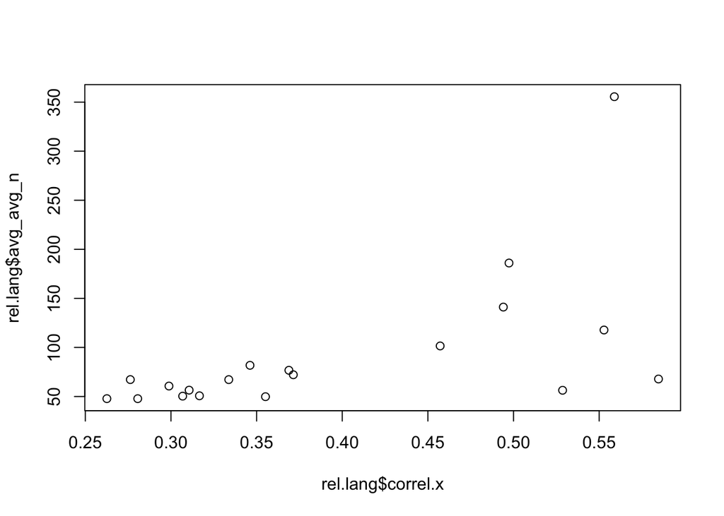

```
##            correl.x   n_unrel     n_rel avg_avg_n
## correl.x  1.0000000 0.5915562 0.5810573 0.5866746
## n_unrel   0.5915562 1.0000000 0.9974589 0.9993633
## n_rel     0.5810573 0.9974589 1.0000000 0.9993657
## avg_avg_n 0.5866746 0.9993633 0.9993657 1.0000000
```

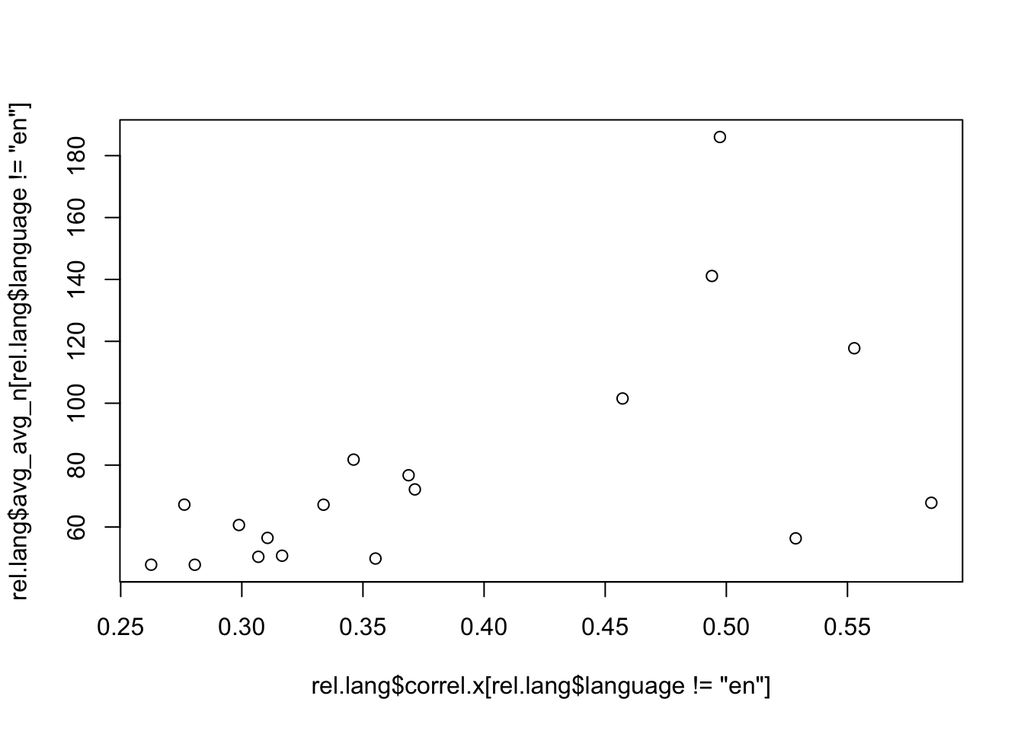

```
## (Intercept)
##     556.796
```

### Reliability for Rescored Accuracy

| Language | Item Reliability | Person Reliability |
| --- | --- | --- |
| br_pt | 0.51 | 0.08 |
| cs | 0.55 | -0.01 |
| da | 0.47 | 0.14 |
| de | 0.67 | -0.01 |
| el | 0.41 | 0.01 |
| en | 0.72 | 0.06 |
| es | 0.63 | 0.08 |
| fr | 0.46 | -0.05 |
| hu | 0.47 | 0.03 |
| it | 0.54 | 0.12 |
| ja | 0.74 | 0.17 |
| ko | 0.69 | 0.01 |
| pl | 0.52 | 0.12 |
| pt | 0.45 | 0.12 |
| ro | 0.48 | -0.04 |
| ru | 0.71 | 0.17 |
| sr | 0.44 | 0.20 |
| tr | 0.66 | 0.01 |
| zh | 0.53 | 0.10 |

### Correlation of Reliability and Sample Size

```
##            correl.x   n_unrel     n_rel avg_avg_n
## correl.x  1.0000000 0.5983271 0.5935922 0.5960417
## n_unrel   0.5983271 1.0000000 0.9993748 0.9998422
## n_rel     0.5935922 0.9993748 1.0000000 0.9998452
## avg_avg_n 0.5960417 0.9998422 0.9998452 1.0000000
```

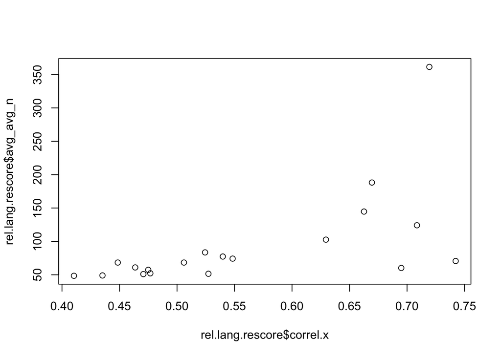

[output not shown]

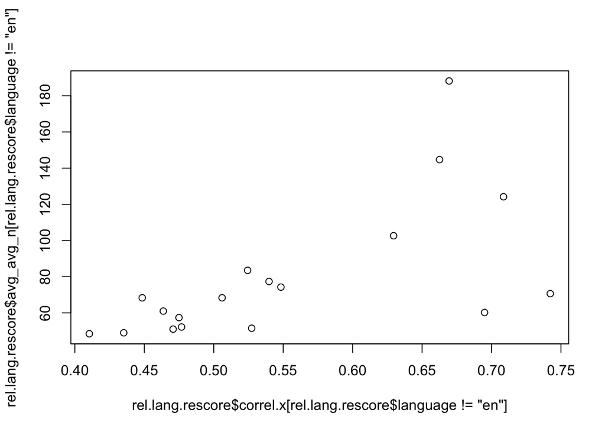

```
## (Intercept)
##    368.5274
```

Aguasvivas, Jose Armando, Manuel Carreiras, Marc Brysbaert, Paweł Mandera, Emmanuel Keuleers, and Jon Andoni Duñabeitia. 2018. “SPALEX: A Spanish Lexical Decision Database from a Massive Online Data Collection.” *Frontiers in Psychology* 9 (November): 2156. https://doi.org/10.3389/fpsyg.2018.02156.

Buchanan, Erin, Kelly Cuccolo, Tom Heyman, Aishwarya Iyer, Nicholas Coles, Neil Lewis Jr, Kim Peters, et al. 2024. “SemanticPriming/SPAML: SPAML V1 Data Release.” Zenodo. https://doi.org/10.5281/ZENODO.10888833.

Chang, Winston, Joe Cheng, JJ Allaire, Carson Sievert, Barret Schloerke, Yihui Xie, Jeff Allen, Jonathan McPherson, Alan Dipert, and Barbara Borges. 2023. “Shiny: Web Application Framework for r.” https://CRAN.R-project.org/package=shiny.

Kremer, Gerhard, and Marco Baroni. 2011. “A Set of Semantic Norms for German and Italian.” *Behavior Research Methods* 43 (1): 97–109. https://doi.org/10.3758/s13428-010-0028-x.

Montefinese, Maria, Ettore Ambrosini, Beth Fairfield, and Nicola Mammarella. 2013. “Semantic Memory: A Feature-Based Analysis and New Norms for Italian.” *Behavior Research Methods* 45 (2): 440–61. https://doi.org/10.3758/s13428-012-0263-4.

Ruts, Wim, Simon De Deyne, Eef Ameel, Wolf Vanpaemel, Timothy Verbeemen, and Gert Storms. 2004. “Dutch Norm Data for 13 Semantic Categories and 338 Exemplars.” *Behavior Research Methods, Instruments, & Computers* 36 (3): 506–15. https://doi.org/10.3758/BF03195597.